# Part2: TAD-Insulation and Intra-TAD Interactions

Author

Xiaohan Xie

## 0. Overview

This section investigates how SARS-CoV-2 infection perturbs chromatin architecture at the level of topologically associating domains (TADs). Specifically, we reproduce three analyses from the original study:

Specifically, we aim to reproduce the following analyses in the original paper: 1. Boundary integrity: whether TAD boundary strength changes upon infection; 2. Intra-TAD interactions: whether contact frequency within TADs is altered; 3. Direct comparison of Hi-C contact matrices at a representative TAD domain.

```r
library(HiCExperiment)
library(HiContacts)
library(GenomicRanges)
library(InteractionSet)
library(rtracklayer)
library(tidyverse)
library(epiwraps)
library(patchwork)
library(GenomicFeatures)
```

## 1. Data Preparation

Using the command line tool of cooler, we merged the replicates for Mock and SARS-CoV-2-infected conditions. In accordance with the original study’s methods, we processed the data at 10kb resolution. Because the paper does not specify a normalisation procedure in detail, we applied cooler’s built-in matrix-balancing algorithm to correct for coverage biases and generated balanced contact scores, which were used throughout the downstream analysis. Lastly, we performed matrix coarsening to generate multi-resolution data, as this was needed for the calculation of insulation scores.

We limited our analysis to chromosome 14 to reduce the computational complexity.

```bash
cooler merge merged_mock_HiC.mcool mock_HiC_rep1.mcool::/resolutions/10000 mock_HiC_rep2.mcool::/resolutions/10000
cooler merge merged_cov_HiC.mcool cov_HiC_rep1.mcool::/resolutions/10000 cov_HiC_rep2.mcool::/resolutions/10000
cooler balance merged_mock_HiC.mcool
cooler balance merged_cov_HiC.mcool
cooler zoomify -r 10000,200000 merged_mock_HiC.mcool -o merged_mock_HiC_multi.mcool
cooler zoomify -r 10000,200000 merged_cov_HiC.mcool -o merged_cov_HiC_multi.mcool
```

```r
hic_mock_merged <- HiCExperiment("./GSE179184_RAW/merged_mock_HiC_multi.mcool", focus = "chr14", resolution = 10000)
hic_cov_merged <- HiCExperiment("./GSE179184_RAW/merged_cov_HiC_multi.mcool", focus = "chr14", resolution = 10000)
length(hic_mock_merged)
```

```
[1] 3829954
```

```r
length(hic_cov_merged)
```

```
[1] 3728822
```

```r
summary(interactions(hic_mock_merged)$balanced)
```

```
     Min.   1st Qu.    Median      Mean   3rd Qu.      Max.       NAs
5.846e-05 2.257e-04 3.452e-04 1.193e-03 6.174e-04 2.909e-01     43969
```

```r
summary(interactions(hic_cov_merged)$balanced)
```

```
     Min.   1st Qu.    Median      Mean   3rd Qu.      Max.       NAs
5.072e-05 2.495e-04 3.922e-04 9.968e-04 6.773e-04 1.201e-01     57439
```

Mock sample has slightly more interaction counts than the CoV-infected group. Both samples show highly skewed distribution, with the majority of interactions having very low balanced scores, which is expected for Hi-C data.

## 2. Insulation Scores and Boundary strengths

According to methods decribed in the original paper, we calculated the insulation scores using getDiamondInsulation, setting a 200kb sliding window. TAD boundaries were then called by finding the local minima in the insulation profile with a threshold of 0.5.

```r
hic_mock <- getDiamondInsulation(hic_mock_merged, window_size = 200000)
hic_cov <- getDiamondInsulation(hic_cov_merged, window_size = 200000)
hic_mock <- getBorders(hic_mock, strong_threshold = 0.5)
hic_cov <- getBorders(hic_cov, strong_threshold = 0.5)
bounds_mock <- topologicalFeatures(hic_mock, 'borders')
bounds_cov <- topologicalFeatures(hic_cov, 'borders')
```

To allow a direct, position-matched comparison between conditions, we pooled the boundaries called in the Mock and infected samples into a single consensus set, as done in the original study.

```r
merged_bounds <- GenomicRanges::reduce(c(bounds_mock, bounds_cov))
merged_bounds <- merged_bounds[seqnames(merged_bounds) == "chr14"]
head(merged_bounds)
```

```
GRanges object with 6 ranges and 0 metadata columns:
      seqnames            ranges strand
         <Rle>         <IRanges>  <Rle>
  [1]    chr14 19250001-19260000      *
  [2]    chr14 19460001-19470000      *
  [3]    chr14 19790001-19800000      *
  [4]    chr14 20000001-20010000      *
  [5]    chr14 20690001-20700000      *
  [6]    chr14 20740001-20750000      *
  -------
  seqinfo: 25 sequences from an unspecified genome
```

```r
ins_track_mock <- metadata(hic_mock)$insulation
ins_track_cov <- metadata(hic_cov)$insulation
```

We then used the `epiwraps` package to visualise insulation-score profiles centred on the consensus boundaries, extending 500 kb up- and downstream of each boundary.

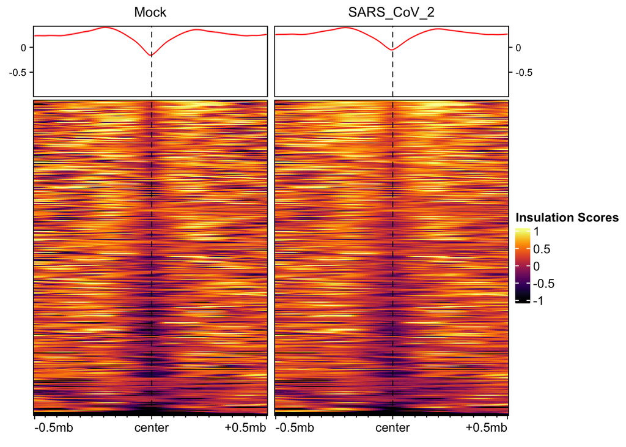

Insulation scores calculated TAD boundaries in both conditions.

```r
ins_track_mock$score <- ins_track_mock$insulation
ins_track_cov$score  <- ins_track_cov$insulation
tracks <- list(Mock = ins_track_mock, SARS_CoV_2 = ins_track_cov)
ins <- signal2Matrix(tracks, regions = merged_bounds, extend = 500000, w = 10000)
plotEnrichedHeatmaps(ins, scale_title ="Insulation Scores", use_raster = FALSE)
```

We can see that although CoV-infected group shows a slightly higher insulation score at the consensus boundaries, this effect is rather mild, consistent with the original study (Fig.4d). This indicates that TAD boundary strength is largely preserved upon infection.

## 3. TADs and Intra-TAD Interaction

We then further obtained the TADs, defined as genomic intervals nested between the previously identified consensus boundaries.

```r
# gaps between merged boundaries are TADs
merged_tads <- gaps(merged_bounds)
merged_tads <- merged_tads[strand(merged_tads) == "*"]
merged_tads <- merged_tads[seqnames(merged_tads) == "chr14"]
# filter out extremely small fragments (as we have resolution of 10000, use threshold 20000)
merged_tads <- merged_tads[width(merged_tads) >= 20000]
# get the GInteractions objects
gi_mock <- interactions(hic_mock)
gi_cov <- interactions(hic_cov)
# filter out very short distant interactions (< 15 kb)
gi_mock_sub <- gi_mock[pairdist(gi_mock) >= 15000]
gi_cov_sub <- gi_cov[pairdist(gi_cov) >= 15000]
```

To quantify the intra-TAD interactions, we defined a helper function to isolate interactions that occur strictly within the same TAD domain. We then computed the mean balanced contact score per TAD for each condition.

```r
# func to map interactions inside TADs
get_intra_tad_means <- function(gi_filtered, tads) {

  hits1 <- findOverlaps(anchors(gi_filtered, type="first"), tads)
  hits2 <- findOverlaps(anchors(gi_filtered, type="second"), tads)

  # keep only interactions where both anchors found in the same TAD
  common_hits <- inner_join(
    as.data.frame(hits1),
    as.data.frame(hits2),
    by = "queryHits", suffix = c("1", "2")
  ) %>% filter(subjectHits1 == subjectHits2)

  # aggregate mean contact score per TAD

  df <- data.frame(
    tad_idx = common_hits$subjectHits1,
    contact_val = gi_filtered$balanced[common_hits$queryHits]
  )

  df_mean <- df %>%
    group_by(tad_idx) %>%
    summarize(mean_contact = mean(contact_val, na.rm = TRUE))

  return(df_mean)
}

mock_means <- get_intra_tad_means(gi_mock_sub, merged_tads)
cov_means <- get_intra_tad_means(gi_cov_sub, merged_tads)
```

To compare conditions, we then computed, for each TAD, the log2 fold-change of the mean contact score (SARS-CoV-2 relative to Mock).

```r
tad_metrics <- data.frame(tad_id = 1:length(merged_tads)) %>%
  left_join(mock_means, by = c("tad_id" = "tad_idx")) %>%
  rename(Mock_Mean = mean_contact) %>%
  left_join(cov_means, by = c("tad_id" = "tad_idx")) %>%
  rename(Cov_Mean = mean_contact) %>%
  mutate(
    log2FC = log2((Cov_Mean) / (Mock_Mean))
  )

# save it as a col
mcols(merged_tads) <- tad_metrics
```

We then visualised the distribution of these log2FCs.

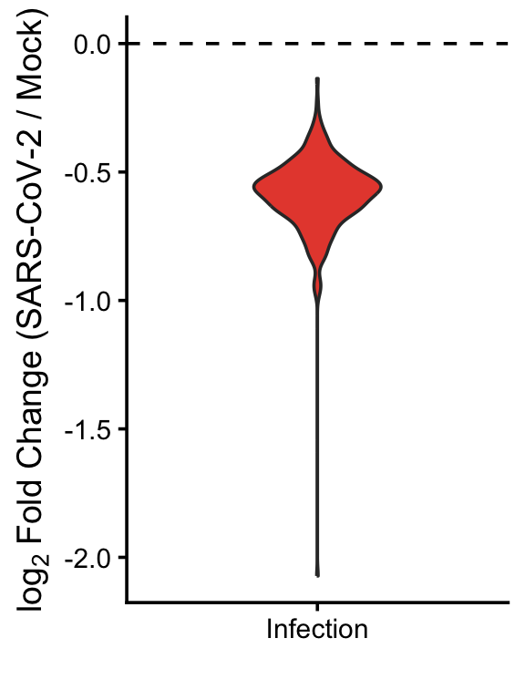

log2FCs of intra-TAD Hi-C interactions.

```r
# Fig.4c: boxplot of intra-TAD interaction changes
ggplot(tad_metrics, aes(x = "Infection", y = log2FC)) +
  geom_violin(fill = "#E74C3C", width = 0.4) +
  geom_hline(yintercept = 0, linetype = "dashed", color = "black") +
  labs(
    x = "",
    y = expression(log[2]~"Fold Change (SARS-CoV-2 / Mock)")
  ) +
  theme_classic(base_size = 14)
```

It can be seen from the plot that SARS-CoV-2 infection reduces the intra-TAD contacts, which aligns with the findings of the paper.

## 4. Hi-C Matrices at a Specific TAD Domain

Following the original study (Fig.4a), we defined a specific TAD domain of interest on chromosome 14 and visualised Hi-C contacts at this region. We proceeded with bin size of 10kb, unlike in the paper, where the authors switched to a resolution of 5kb for this analysis. We calculated a differential contact matrix for this TAD region, which we visualised together with the contact matrices of both Mock and CoV groups.

```r
# the target genomic coordinates
target_chr <- "chr14"
target_start <- 71400000
target_end   <- 72600000
target_region <- paste0(target_chr, ":", target_start, "-", target_end)
target_gr <- GRanges(seqnames = target_chr, ranges = IRanges(target_start, target_end))

hic_mock_reg <- refocus(hic_mock, target_region)
hic_cov_reg <- refocus(hic_cov,  target_region)

hic_div      <- divide(hic_cov_reg, by = hic_mock_reg, use.scores = "balanced")
```

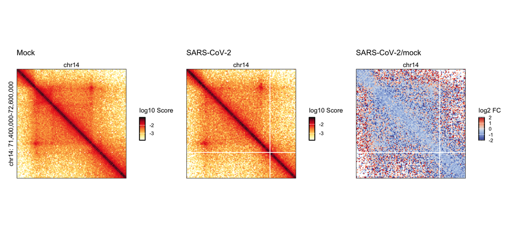

Hi-C matrices (bin size = 10 kb) at the indicated region (hg19) and log2FC after infection.

```r
# mock
p_matrix_mock <- plotMatrix(hic_mock_reg, use.scores = "balanced", scale = "log10", caption = FALSE) +
  labs(title = "Mock", fill = "log10 Score", y = paste0(target_chr, ": 71,400,000-72,600,000")) +
  theme(axis.text = element_blank(), axis.ticks = element_blank())

# cov
p_matrix_cov <- plotMatrix(hic_cov_reg, use.scores = "balanced", scale = "log10", caption = FALSE) +
  labs(title = "SARS-CoV-2", fill = "log10 Score") +
  theme(axis.title.y = element_blank(), axis.text = element_blank(), axis.ticks = element_blank())

# log2 FC
p_matrix_l2fc <- plotMatrix(
  hic_div,
  use.scores = "balanced.l2fc",
  scale = "linear",
  cmap = bgrColors(), caption = FALSE,
  limits = c(-2, 2)
) +
  labs(title = "SARS-CoV-2/mock", fill = "log2 FC") +
  theme(axis.title.y = element_blank(), axis.text = element_blank(), axis.ticks = element_blank())

matrix_panels <- p_matrix_mock + p_matrix_cov + p_matrix_l2fc +
  plot_layout(ncol = 3)

matrix_panels
```

The patterns here indicate that while intra-TAD interactions tend to be reduced by infection of SARS-CoV-2, contacts outside of TADs (off-diagonal) are largely unaltered or even increased. This was demonstrated more comprehensively by the Aggregate Domain Analysis in the original paper (Fig.4b). Looking at the contact matrices of the two groups (Mock and CoV), we can also see that TAD-boundaries are not noticeably perturbed by infection, corroborating the results of the insulation score analysis.

## 5. Discussion

This part of the analysis shows that SARS-CoV-2 infection selectively weakens intra-TAD interactions, while leaving TAD boundaries and inter-TAD contacts largely intact.

It should be noted that our pipeline does not exactly replicate the original methods, since the paper did not fully specify several parameter choices. We were also unable to reproduce the Aggregate Domain Analysis due to a persistent function error that we could not resolve.

Despite these methodological differences, the trends we recovered from this part align well with the conclusions of the original paper.